# lab-06

Author

Katie Zhao

# **Lab 6 - Text Mining**

**Learning goals:**

- Use `unnest_tokens()` and `unnest_ngrams()` to extract tokens and n-grams from text.
- Use dplyr and ggplot2 to analyze text data

**Lab description:**

For this lab (due Tuesday Feb 24th at 8:30am EST) we will be working with a new text-based dataset consisting of transcribed medical reports. The dataset contains transcription samples from https://www.mtsamples.com/. We have created a (somewhat) cleaned version of the data, which can be found at https://raw.githubusercontent.com/dmcable/BIOSTAT620W26/main/data/mtsamples/mtsamples.csv.

### **Setup packages:**

```r
library(tidyverse)
library(dplyr)
library(ggplot2)
library(tidytext)
```

### **Read in Medical Transcriptions:**

Loading in the cleaned data from the `BIOSTAT620W26` repository:

```r
url <- 'https://raw.githubusercontent.com/dmcable/BIOSTAT620W26/main/data/mtsamples/mtsamples.csv'
if (!file.exists("mtsamples.csv"))
  download.file(
    url = url,
    destfile = "mtsamples.csv",
    method   = "libcurl",
    timeout  = 60
    )
mtsamples <- read.csv('mtsamples.csv')
```

## **Question 1: What specialties do we have?**

Use the `count()` function from `dplyr` to figure out how many different categories we have in the data. Are these categories related? Overlapping? Evenly distributed?

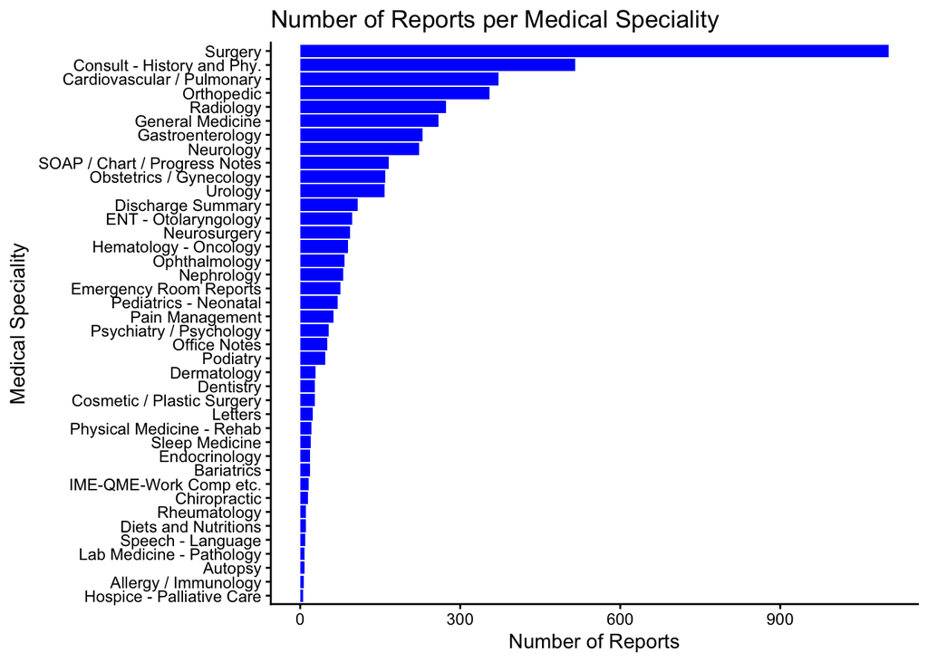

```r
mtsamples %>%
  count(medical_specialty, sort=TRUE) %>%
  ggplot(aes(n, fct_reorder(medical_specialty, n))) +
  geom_col(fill = "blue") +
  theme_classic() +
  labs(x = "Number of Reports",
       y = "Medical Speciality",
       title = "Number of Reports per Medical Speciality")
```

There are 40 different categories of medical specialties in the data, but the data/medical reports are not evenly distributed between each category.

## **Question 2**

- Tokenize the the words in the `transcription` column
- Count the number of times each token appears
- Visualize the top 20 most frequent words

Explain what we see from this result. Does it makes sense? What insights (if any) do we get?

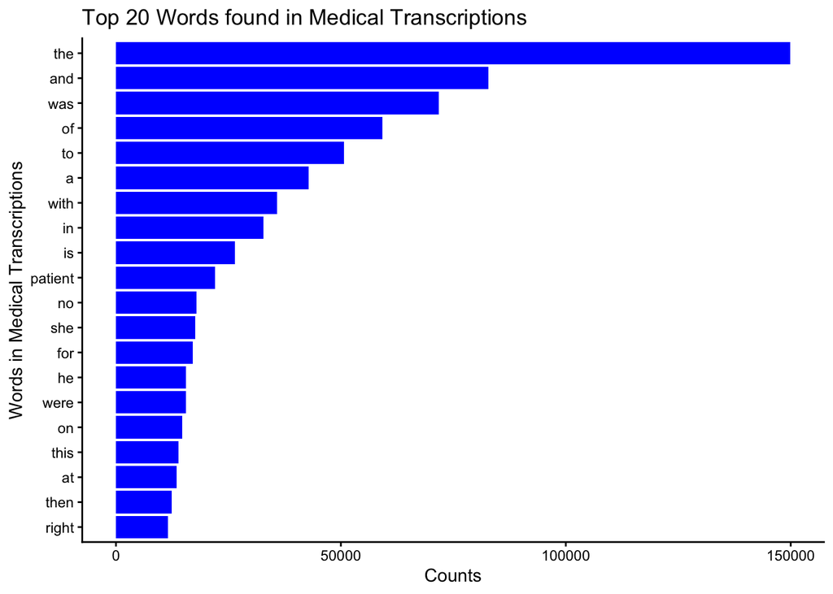

```r
mtsamples %>%
  unnest_tokens(token, transcription) %>%
  count(token) %>%
  top_n(20, n) %>%
  ggplot(aes(n, fct_reorder(token, n))) +
  geom_col(fill = "blue") +
  theme_classic() +
  labs(x = "Counts",
       y = "Words in Medical Transcriptions",
       title = "Top 20 Words found in Medical Transcriptions")
```

It makes sense that the top 20 words found in these transcriptions are generally “filler words,” like *the, and, was, of, to,* etc (preposition/article words commonly used in the English language). This does not provide much insight about this particular medical dataset, because other than “patient,” it could be argued that these words could arise from data in almost any context. There are not any “unique” or “proper noun”-esque words that are found in this top 20 words list.

## **Question 3**

- Re-do the visualization but remove stop words before making it
- Bonus points if you remove numbers as well

What do we see know that we have removed stop words? Does it give us a better idea of what the text is about?

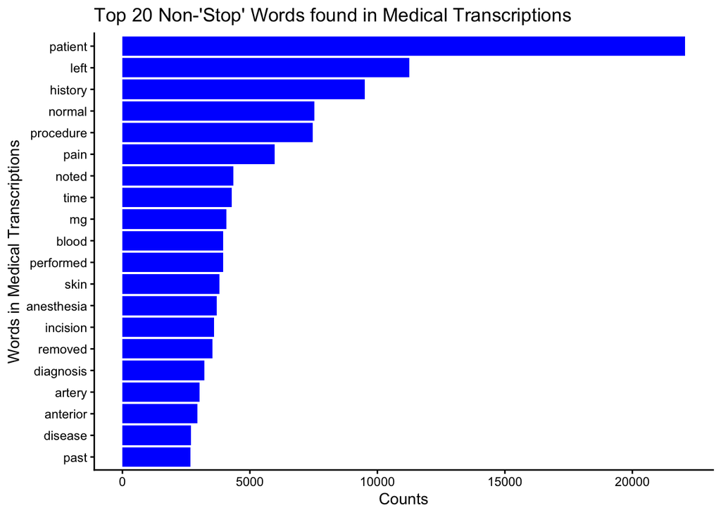

```r
mtsamples %>%
  unnest_tokens(word, transcription) %>%
  anti_join(stop_words, by = c("word")) %>%
  filter(is.na(as.numeric(word))) %>%
  count(word) %>%
  top_n(20, n) %>%
  ggplot(aes(n, fct_reorder(word, n))) +
  geom_col(fill = "blue") +
  theme_classic() +
  labs(x = "Counts",
       y = "Words in Medical Transcriptions",
       title = "Top 20 Non-'Stop' Words found in Medical Transcriptions")
```

Now, more “proper noun” / “unique” words appear in the top 20 words list, after stop words and numbers have been removed. Words such as anesthesia, artery, blood, pain, and procedure help provide more context/clarity in the data that these are medical related texts.

# **Question 4**

Repeat question 2, but this time tokenize into bi-grams. How does the result change if you look at tri-grams?

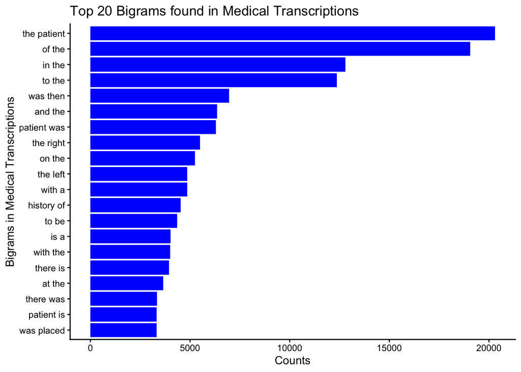

```r
mtsamples %>%
  unnest_ngrams(ngrams, transcription, n = 2) %>%
  count(ngrams) %>%
  top_n(20, n) %>%
  ggplot(aes(n, fct_reorder(ngrams, n))) +
  geom_col(fill = "blue") +
  theme_classic() +
  labs(x = "Counts",
       y = "Bigrams in Medical Transcriptions",
       title = "Top 20 Bigrams found in Medical Transcriptions")
```

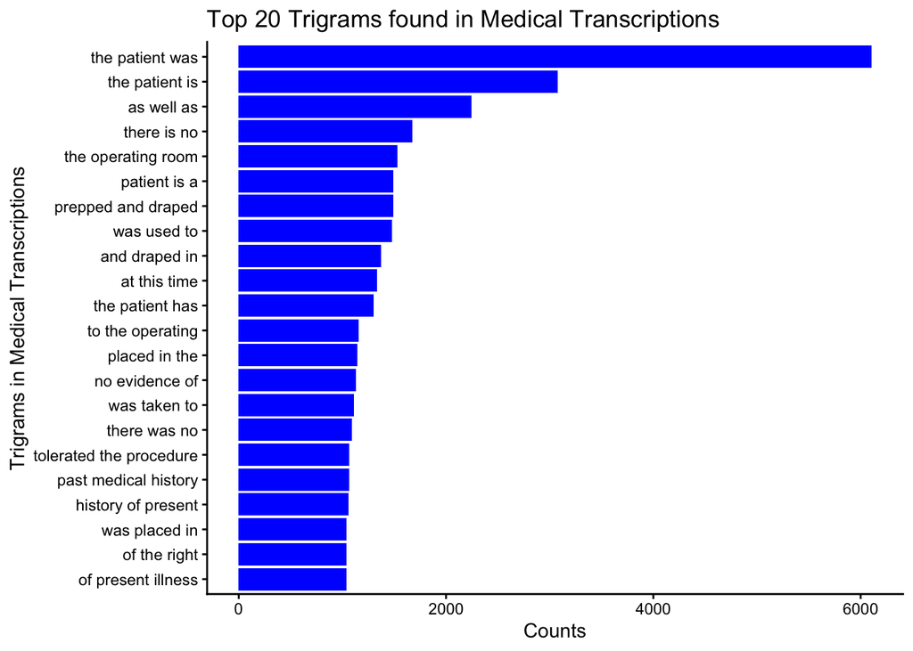

```r
mtsamples %>%
  unnest_ngrams(ngrams, transcription, n = 3) %>%
  count(ngrams) %>%
  top_n(20, n) %>%
  ggplot(aes(n, fct_reorder(ngrams, n))) +
  geom_col(fill = "blue") +
  theme_classic() +
  labs(x = "Counts",
       y = "Trigrams in Medical Transcriptions",
       title = "Top 20 Trigrams found in Medical Transcriptions")
```

Patient appears multiple times in the top bigrams of the medical reports, but so do a lot of article/preposition links, such as “of the” and “in the.” In the trigrams, more “interesting” phrases start to appear that are more related to this medical context. “Prepped and draped,” “the operating room,” “past medical history” are all more concrete phrases that show medical context. Of course, in the trigrams, there is also more verbage attached to the patients (*the patient was, the patient is, the patient has, etc*).

# **Question 5**

Using the results you got from Question 4, pick a word and count the words that appear before and after it.

```r
# BEFORE
mtsamples %>%
  unnest_ngrams(ngrams, transcription, n = 3) %>%
  separate(ngrams, into = c("word1", "word2", "word3"), sep = " ") %>%
  filter(word2 == "patient") %>%
  count(word1, sort=TRUE) %>%
  top_n(5)
```

```
    word1     n
1     the 20294
2    this   463
3 history   101
4       a    67
5     and    47
```

```r
mtsamples %>%
  unnest_ngrams(ngrams, transcription, n = 3) %>%
  separate(ngrams, into = c("word1", "word2", "word3"), sep = " ") %>%
  filter(word2 == "patient") %>%
  count(word3, sort=TRUE) %>%
  top_n(5)
```

```
      word3    n
1       was 6291
2        is 3332
3       has 1417
4 tolerated  994
5       had  886
```

The words that came most often before “patient” were “the” and “this—” articles used before nouns. The words that came most often after “patient” were verbs such as “was” and “is” and “tolerated.” The follows the semantics of the English language, and matches the “Top 20 Trigrams” graph shown above.

# **Question 6**

Which words are most used in each of the specialties? You can use `group_by()` and `top_n()` from `dplyr` to have the calculations be done within each specialty. Remember to remove stop words. What are the 5 most-used words for each specialty?

```r
mtsamples %>%
  unnest_tokens(word, transcription) %>%
  anti_join(stop_words, by = c("word")) %>%
  group_by(medical_specialty) %>%
  count(word) %>%
  top_n(5) %>%  # With group_by, top_n(5) takes top 5 counts from each group
  arrange(medical_specialty, desc(n))
```

```
# A tibble: 209 × 3
# Groups:   medical_specialty [40]
   medical_specialty       word          n
   <chr>                   <chr>     <int>
 1 " Allergy / Immunology" history      38
 2 " Allergy / Immunology" noted        23
 3 " Allergy / Immunology" patient      22
 4 " Allergy / Immunology" allergies    21
 5 " Allergy / Immunology" nasal        13
 6 " Allergy / Immunology" past         13
 7 " Autopsy"              left         83
 8 " Autopsy"              1            66
 9 " Autopsy"              inch         59
10 " Autopsy"              neck         55
# ℹ 199 more rows
```

# **Question 7 - extra**

Find your own insight in the data:

Ideas:

- Interesting n-grams
- See if certain words are used more in some specialties than others

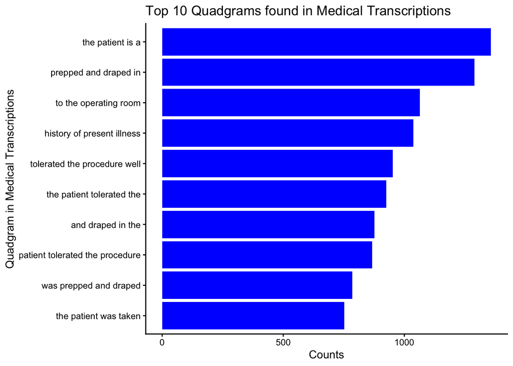

```r
mtsamples %>%
  unnest_ngrams(ngrams, transcription, n = 4) %>%
  count(ngrams) %>%
  top_n(10, n) %>%
  ggplot(aes(n, fct_reorder(ngrams, n))) +
  geom_col(fill = "blue") +
  theme_classic() +
  labs(x = "Counts",
       y = "Quadgram in Medical Transcriptions",
       title = "Top 10 Quadgrams found in Medical Transcriptions")
```

The top quadgrams expand upon the top trigrams seen before.

```r
library(textdata)
get_sentiments("nrc")
```

```
# A tibble: 13,872 × 2
   word        sentiment
   <chr>       <chr>
 1 abacus      trust
 2 abandon     fear
 3 abandon     negative
 4 abandon     sadness
 5 abandoned   anger
 6 abandoned   fear
 7 abandoned   negative
 8 abandoned   sadness
 9 abandonment anger
10 abandonment fear
# ℹ 13,862 more rows
```

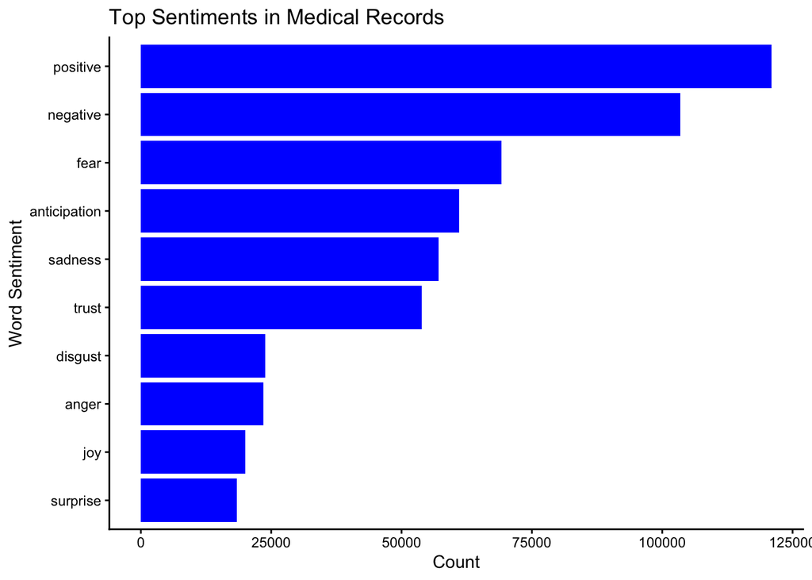

```r
mtsamples %>%
  unnest_tokens(word, transcription) %>%
  inner_join(get_sentiments("nrc"), by = c("word")) %>%
  count(sentiment) %>%
  ggplot(aes(n, fct_reorder(sentiment, n))) +
  geom_col(fill = "blue") +
  theme_classic() +
  labs(x = "Count",
       y = "Word Sentiment",
       title = "Top Sentiments in Medical Records")
```

The top sentiments seen in the record were *positive, negative, fear, anticipation, and sadness*. Seeing *positive* be the top sentiment was a little surprising (in a good way!).